# 파이썬

- 프로그래밍 언어
  - 프로그래밍은 원하는 작업을 컴퓨터에게 시키는 것
  - 컴퓨터에게 내리는 명령어 형식이라고도 볼 수 있다.
- 1991년 귀도 반 로섬이 만든 인터프리터 언어
- 인터프리터 언어란 한 줄 씩 소스 코드를 해석해서 그때그때 실행해 결과를 바로 확인할 수 있는 언어이다.

# 변수 & 데이터타입

- 변수
  - 숫자, 문자열, 리스트 등의 값을 가리키는 것(객체를 가리킨다.)
  - 값을 담아 놓는 공간이라고 생각할 수도 있다.
- 데이터타입
  - 말 그대로 데이터의 타입(형식)을 의미
  - 파이썬에는 숫자(int, float, complex), 문자열(string), 불(bool), 컬렉션(list, dict, set, tuple), None 등이 있다.

# 조건문 & 반복문

- 조건문(if)
  - 조건에 따라 프로그램의 흐름을 제어하기위한 구문
  - 파이썬에서는 if / elif / else 형식으로 표현
- 반복문(for/while loop)
  - 특정 반복조건에 따라 코드 블록을 반복시키기 위한 구문

# 함수

- 특정 코드를 재사용할 수 있도록 구성한 코드 형태
- 인풋과 아웃풋이 있다

# 컬렉션

- 컬렉션 데이터 타입들은 기본적으로 여러 값을 묶어서 사용하기 위한 형태
  - 리스트: 변경 가능하며 인덱싱이 가능(순서가 있다.) `[]`
  - 딕셔너리: 변경 가능하며 key-value형태 `{}`
  - 튜플: 리스트와 비슷하지만 변경 불가능(immutable) `()`
  - 셋: 키가 없는 딕셔너리 형태, 순서가 없다, 집합을 나타내기 위한 형태

# 클래스

- (객체지향 프로그래밍에서 상태(값-변수)와 행위(처리-함수)를 하나의 묶음 형태로 사용하는) 객체의 설계도
- 클래스의 실체가 바로 객체
- 클래스에 의해 만들어진 객체 == 인스턴스(실제 메모리에 올라가 있음)

  쿠키틀 == 클래스/쿠키 == 객체/쿠키 == 쿠키틀의 인스턴스 즉, 쿠키틀이라는 클래스와의 관계를 내포하여 말할 때에는 인스턴스

# 모듈

- 함수나 변수, 클래스를 모아놓은 하나의 파이썬 파일 (~~.py)

Tip

- += 과 for문을 같이 쓸 때 헷갈려하는 분들을 위해!

```python
#리스트 numbers에서 2의 배수만 리스트 results에 넣어보자 (for 문 사용)
numbers = [1,2,3,4,5,6,7,8]
results = []
for number in numbers:
    if number % 2 == 0:
        results += [number]
        #위 코드는 result.append(number)과 동일한 작업 수행

print(results)
```

```
[2, 4, 6, 8]
```

- 더 나아가서 위의 예시를 List comprehension을 이용해서!

```python
#리스트 numbers에서 2의 배수만 리스트 results에 넣어보자(List comprehension 사용)
numbers = [1,2,3,4,5,6,7,8]
results = [number for number in numbers if number % 2 == 0]
print(results)
```

```
[2, 4, 6, 8]
```

# Lambda

- 람다 표현식은 익명 함수을 만드는 방식
- 익명 함수는 말 그대로 함수 이름이 없는 함수
- 람다 표현식으로 만든 익명 함수는 변수에 할당하여 호출할 수 있음

def lambda(parameters):

```
return expression
```

lambda parameters(매개변수): expression(매개변수를 이용한 구문)

- 언제 사용할까?
  - 함수를 한 줄로 간결하게 표현할 때
  - 간단한 함수를 굳이 def를 사용하지 않고 만들 때

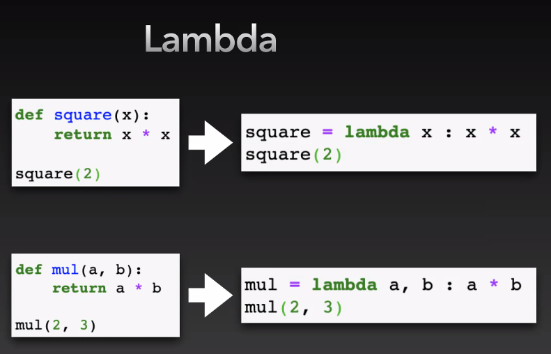

```python
def square(x):
    return x*x
square(2)
```

```
4
```

```python
square = lambda x : x*x
square(2)
```

```
4
```

```python
def mul(a,b):
    return a*b
mul(2,3)
```

```
6
```

```python
mul = lambda a,b:a*b
mul(2,3)
```

```
6
```

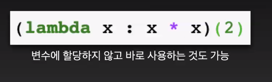

```python
(lambda x: x*x)(2)
```

```
4
```

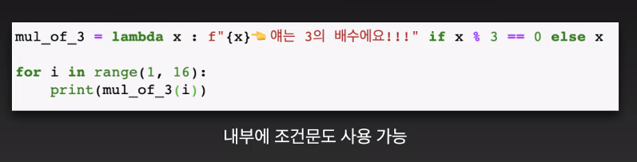

```python
mul_of_3 = lambda x: f"{x}<-얘는 3의 배수에요!" if x % 3 == 0 else x
for i in range(1,16):
    print(mul_of_3(i))
```

```
1
2
3<-얘는 3의 배수에요!
4
5
6<-얘는 3의 배수에요!
7
8
9<-얘는 3의 배수에요!
10
11
12<-얘는 3의 배수에요!
13
14
15<-얘는 3의 배수에요!
```

# 질문 톺아보기!

```python
#띄어쓰기 상관없다
a = 'apple'
"This is %s" % a
"This is %s"%a
```

```
'This is apple'
```

```python
#a넣어도 되고 d넣어도 됨!
scores = [90,100,70]
for score in scores:
    print("%a점에 대한 합격여부 판단"% score)
    if score >= 70:
        print("합격")
    else:
        print("불합격")
```

```
90점에 대한 합격여부 판단
합격
100점에 대한 합격여부 판단
합격
70점에 대한 합격여부 판단
합격
```

함수:

- 매개변수(입력값을 표현하는 변수로써 함수내에서 해당 변수명으로 사용된다.)
- 전달인자(함수에게 전달해주는 인자)

```python
#map
numbers = [1,2,3,4,5,6,7,8,9,10]
def x2(number):
    return number * 2

map(x2, numbers)
numbers
```

```
[1, 2, 3, 4, 5, 6, 7, 8, 9, 10]
```

# 알고리즘 기초#2

1. 최대값 찾기
2. 동명이인 찾기

## 최대값 찾기

- n개의 숫자가 있을 때 최대값을 찾는 알고리즘을 구하라!

```python
def find_max(a):
    n = len(a)
    max_value = a[0]
    for i in range(1,n):
        if a[i] > max_value:
            max_value = a[i]

    return max_value

num_list = [12,1,5,28,20,46,36,21]
print(find_max(num_list))
```

```
46
```

```python
#파이썬에서 리스트를 사용할 때에는 이런 것도 가능(max)
print(max(num_list))
```

```
46
```

- n개의 숫자가 있을 때 최대값의 인덱스(index)를 찾는 알고리즘을 구하라!

```python
def find_max_index(a):
    n = len(a)
    max_index=0
    for i in range(1,n):
        if a[i] > a[max_index]:
            max_index = i

    return max_index

num_list = [12,1,5,28,20,46,36,21]
print(find_max_index(num_list))
```

```
5
```

## 동명이인 찾기 #1

잠깐! Set(셋)에서 자주 사용하는 기능 알아보기!

```python
s=set()
print(len(s)) #빈 셋이므로 0
print(len({1,2,3})) #자료 개수가 세 개이므로 3
```

```
0
3
```

```python
s={"Tom","Jerry"}
s.add("Ethan") #셋 s에 "Ethan"추가
print(s) #셋은 순서가 없어 인덱싱이 안됨(print 했을 때 순서가 다를 수 있음)
```

```
{'Jerry', 'Tom', 'Ethan'}
```

```python
s = {'Jerry', 'Tom', 'Ethan'}
s.discard("Tom") #셋 s에서 "Tom" 제거
print(s)
```

```
{'Jerry', 'Ethan'}
```

```python
s = {'Jerry', 'Tom', 'Ethan'}
s.clear() #셋을 비운다
print(s)
```

```
set()
```

```python
s = {'Jerry', 'Tom', 'Ethan'}
print("Tom" in s) #셋 s에 "Tom"이 있으므로 True
print("tom" in s) #셋 s에 앞글자가 소문자인 "tom"은 없으므로 False
print("Ben" not in s) #셋 s에 "Ben"이 없으므로 True
```

```
True
False
True
```

- n명의 사람 이름 중에서 같은 이름을 찾아 `셋`으로 만들어 돌려주는 알고리즘을 구하라!

```python
#동명이인 (같은 값)을 찾아 셋(set)으로 반환하는 함수
def find_same_name(a):
    n = len(a)
    result = set()
    for i in range(0,n-1):
        for j in range(i+1, n):
            #print(f"i={i} / j = {j}")
            if a[i] == a[j]: #이름이 같으면
                result.add(a[i]) #찾는 이름을 result에 추가

    return result

names = ["Tom","Jerry","Ethan","Tom"]
find_same_name(names)
```

```
{'Tom'}
```

## 동명이인 찾기 #2

잠깐! 딕셔너리에서 자주 사용하는 기능 알아보기

```python
d = {"Ethan":1, "Paul":2, "Ben":3}
len(d)
```

```
3
```

```python
d = {"Ethan":1, "Paul":2, "Ben":3}
d["Paul"]
```

```
2
```

```python
d["Alice"]=4 #이 때 Alice라는 키가 없으므로 4를 값으로하여 새로 저장
d["Alice"]=5 #이 때 Alice라는 키가 있으므로 5로 덮어씀
print(d)
```

```
{'Ethan': 1, 'Paul': 2, 'Ben': 3, 'Alice': 5}
```

```python
del d["Alice"]
d["Alice"] #Alice라는 키가 지워져 없으므로 키 에러 발생
```

```
---------------------------------------------------------------------------
KeyError                                  Traceback (most recent call last)
<ipython-input-81-dbfbd43db5dd> in <module>
      1 del d["Alice"]
----> 2 d["Alice"] #Alice라는 키가 지워져 없으므로 키 에러 발생

KeyError: 'Alice'
```

```python
d.clear() #딕셔너리의 모든 값을 지움
print(d)
```

```
{}
```

```python
d = {"Ethan":1, "Paul":2, "Ben":3}
print("Ethan" in d) #"Ethan"이라는 키가 딕셔너리 d에 있으므로 True
print("ethan" in d) #"ethan"이라는 키는 딕셔너리 d에 없으므로 False
print("ehtan" not in d) #딕셔너리 d에 없으므로 True
```

```
True
False
True
```

- n명의 사람 이름 중에서 같은 이름을 찾아 `집합`으로 만들어 돌려주는 알고리즘을 구하라!

```
- 리스트 안에서 동명이인을 (딕셔너리로) 어떻게 찾을까?
```

```python
딕셔너리 = {
    "이름#1": 이름#1이 등장한 횟수,
    "이름#2": 이름#2이 등장한 횟수,
    "이름#3": 이름#3이 등장한 회수
}
```

```python
#딕셔너리를 이용하여 동명이인 (중복된 값)을 찾는 함수
def find_same_name_using_dict(a):
    #1단계: 각 이름이 등장한 횟수를 딕셔너리로 만듦
    name_dict = {}
    for name in a:
        if name in name_dict: #이름이 name_dict에 이미 있으면
            name_dict[name] += 1 #등장횟수를 1증가 시킴
        else: #name_dict에 아직 해당 이름이 없으므로
            name_dict[name] = 1 #해당 이름을 키로하고 값을 1로 하여 저장(등장횟수:1)

    #2단계: 만들어진 딕셔너리에 등장횟수가 2이상인 것을 찾아 결과 셋에 추가
    result = set()
    for name in name_dict:
        if name_dict[name] >= 2:
            result.add(name)
    return result

names = ["Tom","Jerry","Ethan","Tom"]
find_same_name_using_dict(names)
```

```
{'Tom'}
```

잠깐! 셋과 딕셔너리

- 중괄호({}) 안에 단순히 데이터값이 나열돼 있으면 셋!
- 중괄호({}) key-value 형태로 데이터가 나열돼 있으면 딕셔너리!

# 알고리즘-재귀호출

1. 팩토리얼
2. 피보나치 수열

# 재귀호출(recursion)이란?

재귀 호출은 함수가 자기 자신을 다시 호출하는 것

## 팩토리얼#1

```python
#1부터 n까지의 합을 구하는 문제를 이용하여 간단히 팩토리얼 구하기
def factorial(n):
    result = 1
    for i in range(1,n+1):
        result *= i
    return result

print(factorial(3))
```

```
6
```

## 팩토리얼#2

```python
#재귀호출을 이용하여 팩토리얼 구현하기
def factorial(n):
    if n <= 1:
        return 1
    return factorial(n-1)*n

print(factorial(3))
```

```
6
```

## 피보나치 수열

- 피보나치 수열은 첫째 및 둘째 항이 1이며 그 뒤의 모든 항이 바로 앞의 두 항의 합인 수열이다. 편의상 0번째 항을 0으로 두기도 한다.
- 피보나치 수열 역시 재귀 호출을 설명할 때 자주 등장하는 예시

```python
#재귀 호출을 이용하여 피보나치 수열의 n번째 항 구하기
def fibo(n):
    if n <= 1:
        return 1
    return fibo(n-1) + fibo(n-2)

for i in range(0,10):
    print(fibo(i))
```

```
1
1
2
3
5
8
13
21
34
55
```